# Lecture3

```r
library(dplyr)
```

```r
library(ggplot2)
```

### Part 1

```r
table7_1 = c(37.0, 36.0, 37.1, 37.1, 36.2, 37.3, 36.8, 37.0, 36.3, 36.9, 36.9, 36.7, 36.8)
```

What is the mean of this dataset?

```r
mean(table7_1)
```

```
## [1] 36.77692
```

What is the median of this dataset?

```r
median(table7_1)
```

```
## [1] 36.9
```

Trim out the bottom and top 10% of values and calculate the mean?

```r
mean(table7_1, trim = 0.1)
```

```
## [1] 36.8
```

What is the mode of this dataset?

https://statisticsglobe.com/mode-in-r-programming-example

```r
#
mode <- function(x) {
  unique_x <- unique(x)
  tabulate_x <- tabulate(match(x, unique_x))
  unique_x[tabulate_x == max(tabulate_x)]
}
```

```r
mode(table7_1)
```

```
## [1] 37.0 37.1 36.8 36.9
```

```r
names(table(table7_1)[table(table7_1) == max(table(table7_1))])
```

```
## [1] "36.8" "36.9" "37"   "37.1"
```

# plot a histogram of table7_1 and add lines to show the measures of central tendency

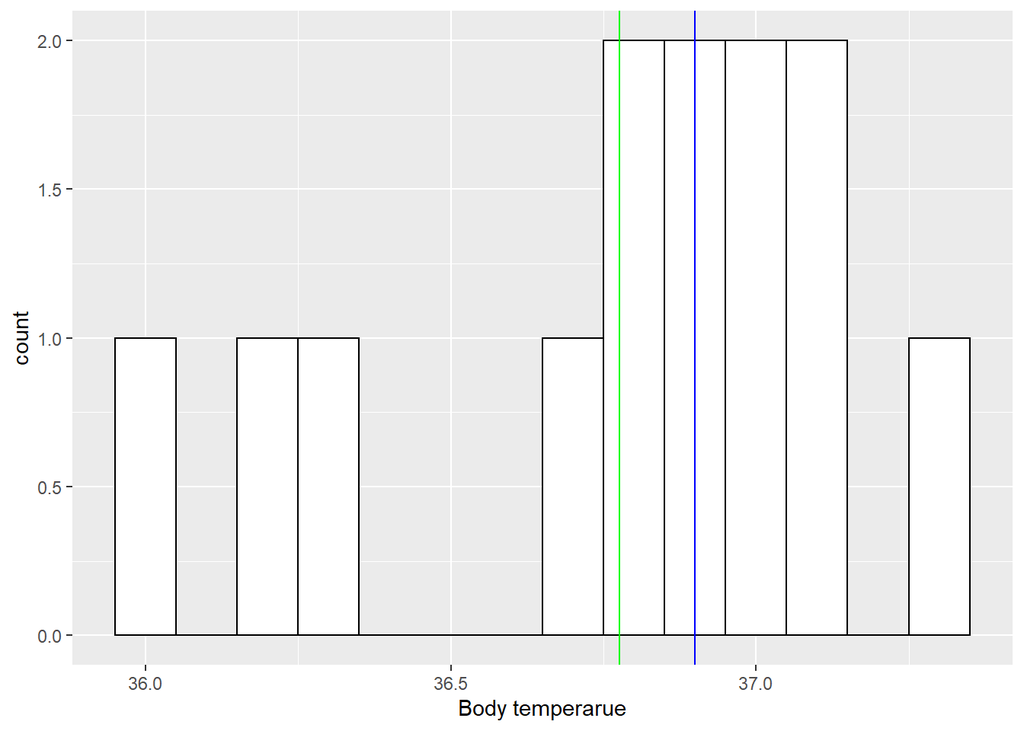

```r
ggplot() +
  aes(table7_1)+
  geom_histogram(binwidth=0.1, colour="black", fill="white")+
  labs(x = "Body temperarue")+
  geom_vline(xintercept = mean(table7_1), colour = "green")+
  geom_vline(xintercept = median(table7_1), colour = "blue")
```

what is the range of this data?

```r
range(table7_1)
```

```
## [1] 36.0 37.3
```

```r
max(table7_1) - mean(table7_1)
```

```
## [1] 0.5230769
```

what is the IQR of this dataset?

```r
IQR(table7_1)
```

```
## [1] 0.3
```

what are the quartiles of this dataset?

```r
quantile(table7_1)
```

```
##   0%  25%  50%  75% 100%
## 36.0 36.7 36.9 37.0 37.3
```

what is the standard deviation of this dataset?

```r
sd(table7_1)
```

```
## [1] 0.3854734
```

what is the variance of this dataset

```r
var(table7_1)
```

```
## [1] 0.1485897
```

##### World bank

the file *worldbank.tsv* contains lots of information on different statistics associated with different countries … lets load this into R

```r
worldbank = read.delim("worldbank.tsv", sep='\t')
worldbank
```

```
##         Climate_region Income_binary                   Country_Name
## 1             Tropical           Low                    Afghanistan
## 2             Tropical           Low                         Angola
## 3   Temperate or Polar          High                        Albania
## 4   Temperate or Polar          High                        Andorra
## 5             Tropical          High           United Arab Emirates
## 6             Tropical          High                      Argentina
## 7   Temperate or Polar          High                        Armenia
## 8             Tropical          High            Antigua and Barbuda
## 9   Temperate or Polar          High                      Australia
## 10  Temperate or Polar          High                        Austria
## 11  Temperate or Polar          High                     Azerbaijan
## 12            Tropical           Low                        Burundi
## 13  Temperate or Polar          High                        Belgium
## 14            Tropical           Low                          Benin
```

[output cut: 1294 more lines]

lets make a histogram of the population growth ….

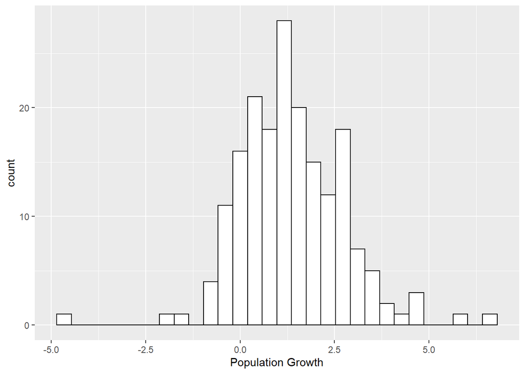

```r
ggplot(data = worldbank, aes(x = Population_growth))+
  geom_histogram(fill = 'white',
                 color = 'black')+
  labs(x = "Population Growth")
```

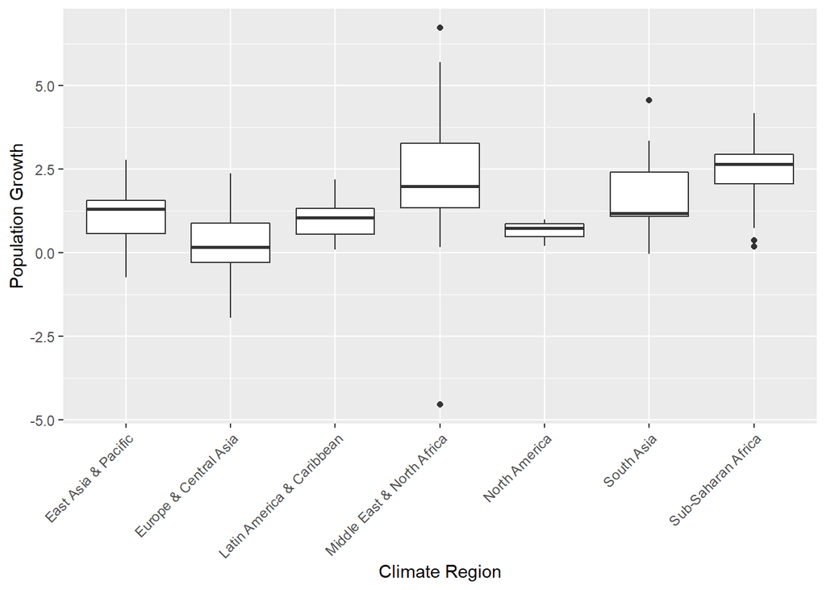

```r
ggplot(data = worldbank, aes(x = Region, y = Population_growth))+
  geom_boxplot()+
  labs(x = "Climate Region",
       y = "Population Growth")+
  theme(axis.text.x = element_text(angle = 45, hjust = 1))
```

```r
# ?stripchart
```

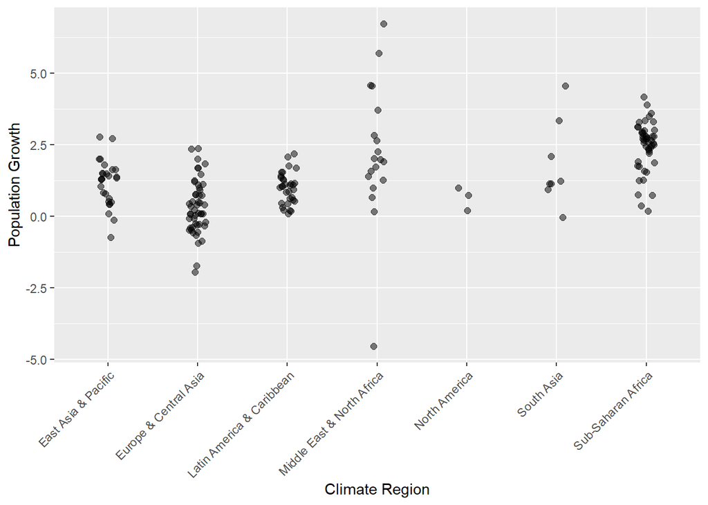

```r
ggplot(data = worldbank, aes(x=Region, y=Population_growth)) +
  geom_jitter(position=position_jitter(0.1), size = 2, alpha = 0.5)+
  labs(x = "Climate Region",
       y = "Population Growth")+
  theme(axis.text.x = element_text(angle = 45, hjust = 1))
```

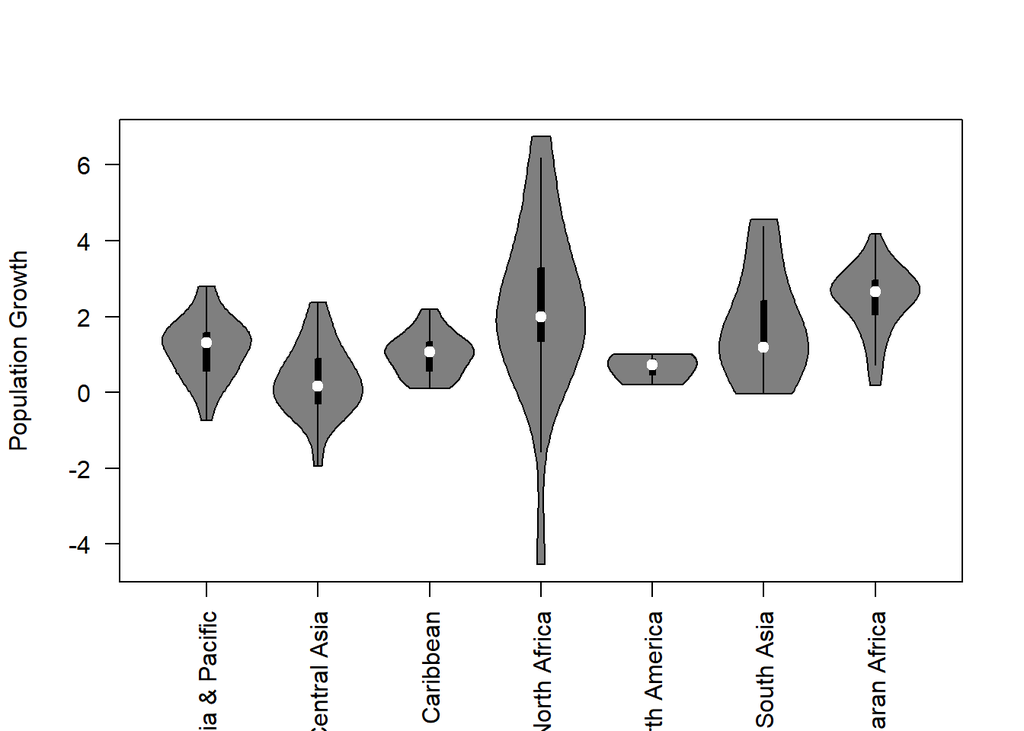

```r
library(vioplot)
vioplot(worldbank$Population_growth ~ worldbank$Region,
        xlab = "", ylab = "Population Growth", las = 2)
```

Plot the cumulative frequency distribution of Population_growth

```r
# ?ecdf
```

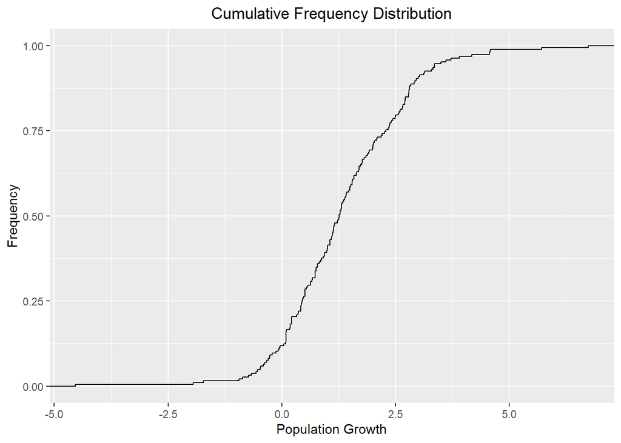

```r
ggplot(data = worldbank, aes(x = Population_growth)) +
  stat_ecdf(geom = "step")+
  labs(x = "Population Growth",
       y = "Frequency",
       title = "Cumulative Frequency Distribution")+
  theme(plot.title = element_text(hjust = 0.5))
```